# Diplomado de Inteligencia Artificial

### Pregunta Extra: murallas fijas

#### Enunciado

Siempre hemos considerado que las murallas del mapa son fijas y no podemos cruzarlas, pero, que ocurre si pudieramos atravesarlas y aparecer al otro lado? Implemente este cambio y cuente sus resultados.

> Implemente el poder atravesar uno de los limites del mapa y aparecer en el otro lado.

Aclaracion: esta es una pregunta opcional y no es requerido responderla para la nota (pero puede haber algo extra ;-).

#### Implementación

**notas**

- lo que se busca es que el héroe pueda atravesar el límite del mapa y aparecer desde el otro lado, actualmente la clase State interpreta el límite como un borde, por lo tanto habría que ajustar la clase:
- se deben ajustar los métodos moveUp, moveDown, moveRight y moveLeft:
  - si el héroe está en la columna más a la derecha y se mueve RIGHT, aparece en la columna 1 de la misma fila
  - si está en la columna 1 y se mueve LEFT, aparece en la última columna.
  - análogamente para UP y DOWN con las filas.

```python
def q(state: State, action: Action = None):
    key = state_key(state)
    if key not in q_table:
        q_table[key] = np.zeros(len(ACTIONS))
    if action is None:
        return q_table[key]
    return q_table[key][action]

def state_key(s: State):
    return (
        s.hero_pos,
        tuple(sorted(s.found_trophies)),
        tuple(sorted(s.found_keys)),
        s.has_sword,
        s.is_win,
    )
```

```python
class State:

    def __init__(
            self,
            grid: Union[Grid, List[List[GridElement]]] = None,
            hero_pos: Tuple[int, int] = (1, 1),
            found_trophies: List[Tuple[int, int]] = None,
            found_keys: List[Tuple[int, int]] = None,
            has_sword: bool = False,
            is_win: bool = False
    ) -> None:

        # trofeos encontrados hasta el momento
        if found_trophies is None:
            found_trophies = []
        self._found_trophies = list(found_trophies)

        # llaves encontradas:
        if found_keys is None:
            found_keys = []
        self._found_keys = list(found_keys)

        self.grid = Grid(grid=grid)
        self.x_lim, self.y_lim = self.grid.shape
        self.hero_x, self.hero_y = hero_pos

        # total de trofeos del juego:
        self._num_pending_trophies = self._count_grid_trophies()

        # espada:
        self._has_sword = has_sword

        # ganado?
        self._is_win = is_win

    # Misma forma `fancy` de acceder a la posicion del heroe
    @property
    def hero_pos(self) -> Tuple[int, int]:
        return (self.hero_x, self.hero_y)

    @property
    def found_trophies(self) -> List[Tuple[int, int]]:
        return self._found_trophies

    @property
    def num_pending_trophies(self) -> int:
        return self._num_pending_trophies

    @property
    def found_keys(self) -> List[Tuple[int, int]]:
        return self._found_keys

    @property
    def has_sword(self) -> bool:
        return self._has_sword

    @property
    def is_win(self) -> bool:
        return self._is_win

    # Para dibujar nuestro mapa con el heroe en la posicion actual
    def __str__(self) -> str:
        grid = deepcopy(self.grid)
        grid[self.hero_x, self.hero_y] = HERO
        return grid.__str__()

    # Un estado es igual a otro si las grillas y posiciones de los heroes son
    # las mismas
    def __eq__(self, other:'State') -> bool:
        return (
            isinstance(other, State)
            and self.hero_pos == other.hero_pos
            and self.grid == other.grid
        )

    # Igual que antes, por completitud debemos implementar cuando 2
    # estados tienen el mismo hash
    def __hash__(self) -> int:
        return hash(
            str(self.grid)
            + str(self.hero_pos)
        )

    # Este metodo nos ayuda a obtener que elemento se encuentra en una posicion
    # determinada. Necesitamos el estado pasado para comparar ya que no tenemos
    # historia, pero es una forma simple de implementar el mapa sin
    # mucho codigo. Recuerda que estamos en una cadena de Markov, aqui no tenemos
    # los estados pasados! Estos no afectan la decision que tomaremos ahora.
    def get_element(self, position:Tuple[int,int], state:'State') -> GridElement:
        assert type(position) == tuple
        assert len(position) == 2
        x, y = position
        assert 0 < x <= self.x_lim
        assert 0 < y <= self.y_lim

        # Por limitaciones de la implementacion, debemos saber si el heroe se
        # movio a la posicion en la que esta, o estaba ahi desde antes
        # otra implementacion podria solucionar este problema de mejor manera
        # pero es mas compleja de entender
        if position == state.hero_pos:
            return HERO
        return self.grid[x,y]

    # De nuestras acciones tenemos que elegir una y actuar acorde a ella.
    # por ejemplo, si le pedimos al estado que suba, entonces tenemos que
    # enviar la accion `UP`.
    # Cuando llamamos a este metodo, creamos un nuevo estado con la
    # accion aplicada
    def action_dispatch(self, action:Action) -> 'State':
        if action == UP:
            return self.moveUp()
        elif action == DOWN:
            return self.moveDown()
        elif action == LEFT:
            return self.moveLeft()
        elif action == RIGHT:
            return self.moveRight()
        else:
            raise ValueError(f"Unknown action {action}")

    # Este metodo solo copia el estado actual y crea uno nuevo para aplicar
    # los cambios pedidos por la accion ingresada
    def register(self) -> 'State':
        past_state = copy(self)
        return State(
            grid=past_state.grid,
            hero_pos=past_state.hero_pos,
            # se agregan nuevos conceptos:
            found_trophies=past_state._found_trophies,
            found_keys=past_state._found_keys,
            has_sword=past_state._has_sword,
            is_win=past_state._is_win
            )

    # funciones modificadas:
    def moveUp(self) -> 'State':
        new_state = self.register()
        # UP: aumenta y. Si se pasa de y_lim, vuelve a 1.
        new_state.hero_y = new_state.hero_y + 1
        if new_state.hero_y > new_state.y_lim:
            new_state.hero_y = 1
        return new_state

    def moveDown(self) -> 'State':
        new_state = self.register()
        # DOWN: disminuye y. Si baja de 1, aparece en y_lim.
        new_state.hero_y = new_state.hero_y - 1
        if new_state.hero_y < 1:
            new_state.hero_y = new_state.y_lim
        return new_state

    def moveRight(self) -> 'State':
        new_state = self.register()
        # RIGHT: aumenta x. Si pasa de x_lim, vuelve a 1.
        new_state.hero_x = new_state.hero_x + 1
        if new_state.hero_x > new_state.x_lim:
            new_state.hero_x = 1
        return new_state

    def moveLeft(self) -> 'State':
        new_state = self.register()
        # LEFT: disminuye x. Si baja de 1, aparece en x_lim.
        new_state.hero_x = new_state.hero_x - 1
        if new_state.hero_x < 1:
            new_state.hero_x = new_state.x_lim
        return new_state

    def _count_grid_trophies(self) -> int:
        contador = 0
        for x in range(1, self.x_lim + 1):
            for y in range(1, self.y_lim + 1):
                if self.grid[x, y] == TROPHIE:
                    contador += 1
        return contador

    def _count_grid_trophies(self) -> int:
        contador = 0
        for x in range(1, self.x_lim + 1):
            for y in range(1, self.y_lim + 1):
                if self.grid[x, y] == TROPHIE:
                    contador += 1
        return contador

    def add_found_trophy(self, pos: Tuple[int, int]) -> None:
        if pos not in self._found_trophies:
            self._found_trophies.append(pos)

    def add_found_key(self, pos: Tuple[int, int]) -> None:
        if pos not in self._found_keys:
            self._found_keys.append(pos)

    def set_has_sword(self, value: bool = True) -> None:
        self._has_sword = value

    def set_is_win(self, value: bool = True) -> None:
        self._is_win = value
```

```python
REWARD_EMPTY_POSITION = -0.5
p8_grid = [
    [TROPHIE, EMPTY, EMPTY],
    [ZOMBIE, ZOMBIE, EMPTY],
    [EMPTY, BLOCK, EMPTY]
]
p8_initial_state = State(grid=p8_grid, hero_pos=(1, 1))
print(p8_initial_state)
```

```
🏆 ⚪ ⚪
🧟 🧟 ⚪
🙃 🚫 ⚪
```

```python
estado = State(grid=p8_grid, hero_pos=(1, 1))
print("Inicial:", estado.hero_pos)

estado = estado.moveLeft()
print("Después de LEFT (debería ser (3, 1)):", estado.hero_pos)

estado = estado.moveRight()
print("Después de RIGHT (debería volver a (1, 1)):", estado.hero_pos)

estado = estado.moveDown()
print("Después de DOWN (debería ser (1, 3)):", estado.hero_pos)

estado = estado.moveUp()
print("Después de UP (debería volver a (1, 1)):", estado.hero_pos)
```

```
Inicial: (1, 1)
Después de LEFT (debería ser (3, 1)): (3, 1)
Después de RIGHT (debería volver a (1, 1)): (1, 1)
Después de DOWN (debería ser (1, 3)): (1, 3)
Después de UP (debería volver a (1, 1)): (1, 1)
```

```python
reset_table()

p8_recompensas_por_episodio, p8_total_done = q_learning(
    start_state = p8_initial_state,
    episodes = 20,
    steps = 10,
    table = q_table,
    learning_rate = alphas,
    discount = gamma,
    imprimir = False,
    toroidal = True
)
```

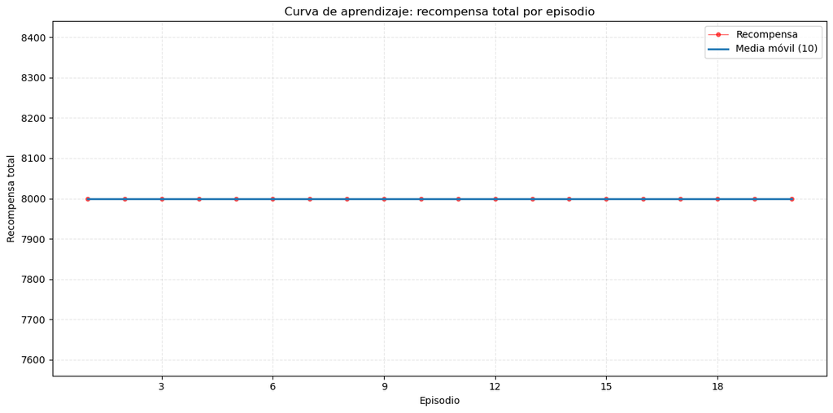

```python
#imprimir_recompensas_por_episodio(p8_recompensas_por_episodio, "purple")
imprimir_recompensas_n_episodios(rewards=p8_recompensas_por_episodio, color_linea="red", window=10)
```

```python
ver_recorrido(p8_initial_state, imprimir=True, toroidal=True)
```

```
[INFO] ver_recorrido(posición héroe): (1, 1)
🏆 ⚪ ⚪
🧟 🧟 ⚪
🙃 🚫 ⚪
 - recompensas por acción: up=1971.01, down=8000.00, left=2178.38, right=1967.02  -> mayor: 8000.00
[INFO] State( hero_pos: (1, 1), action: DOWN, state.num_pending_trophies: 1, found_keys: [], has_sword: False )
 - grid_item: 🏆, new_state.has_sword: False, new_state.hero_pos: (1, 3))
 - new_state.num_pending_trophies: 1, total_trophies_found_before: 0
 - trofeo encontrado en: (1, 3) -> local_pending_trophies: 0
 - cantidad de trofeos pendientes: 1
   - lista de trofeos antes del acto: [], cantidad: 0
   - lista de trofeos ahora: [(1, 3)], cantidad: 1
   - gana juego?: True
 -> return new_state: (1, 3), reward: 8000, is_done: True
🙃 ⚪ ⚪
🧟 🧟 ⚪
⚪ 🚫 ⚪
```

```python
p8_grid_grande = [
    [TROPHIE, EMPTY, EMPTY, EMPTY, ZOMBIE, TROPHIE, BLOCK, BLOCK],
    [ZOMBIE, ZOMBIE, BLOCK, EMPTY, BLOCK, BLOCK, BLOCK, BLOCK],
    [DOOR, EMPTY, EMPTY, EMPTY, BLOCK, BLOCK, BLOCK, BLOCK],
    [TROPHIE, BLOCK, EMPTY, EMPTY, BLOCK, BLOCK, BLOCK, BLOCK],
    [ZOMBIE, EMPTY, EMPTY, EMPTY, EMPTY, EMPTY, EMPTY, BLOCK],
    [EMPTY, EMPTY, BLOCK, EMPTY, BLOCK, BLOCK, EMPTY, BLOCK],
    [EMPTY, ZOMBIE, BLOCK, KEY, BLOCK, BLOCK, EMPTY, BLOCK],
    [EMPTY, EMPTY, EMPTY, BLOCK, BLOCK, BLOCK, SWORD, BLOCK]
]
p8_initial_state_grande = State(grid=p8_grid_grande, hero_pos=(1, 1))
print(p8_initial_state_grande)
```

```
🏆 ⚪ ⚪ ⚪ 🧟 🏆 🚫 🚫
🧟 🧟 🚫 ⚪ 🚫 🚫 🚫 🚫
🚪 ⚪ ⚪ ⚪ 🚫 🚫 🚫 🚫
🏆 🚫 ⚪ ⚪ 🚫 🚫 🚫 🚫
🧟 ⚪ ⚪ ⚪ ⚪ ⚪ ⚪ 🚫
⚪ ⚪ 🚫 ⚪ 🚫 🚫 ⚪ 🚫
⚪ 🧟 🚫 🔑 🚫 🚫 ⚪ 🚫
🙃 ⚪ ⚪ 🚫 🚫 🚫 🗡️ 🚫
```

```python
reset_table()
p8_episodes = 500
alphas = np.linspace(1.0, MIN_ALPHA, p8_episodes)

p8_recompensas_por_episodio_grande, p8_total_done_grande = q_learning(
    start_state = p8_initial_state_grande,
    episodes = p8_episodes,
    steps = 200,
    table = q_table,
    learning_rate = alphas,
    discount = gamma,
    imprimir = False,
    toroidal = True
)
```

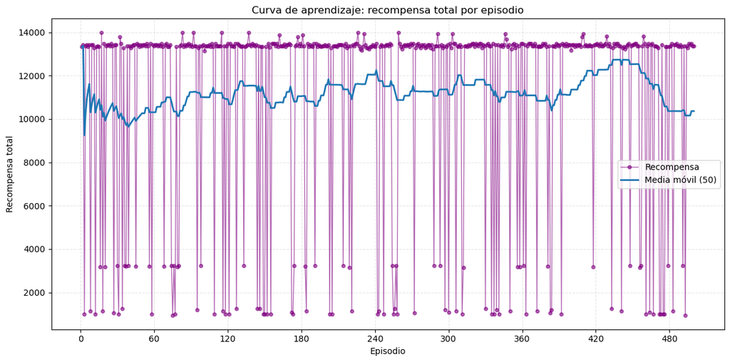

```python
imprimir_recompensas_n_episodios(rewards=p8_recompensas_por_episodio_grande, color_linea="purple", window=50)
```

```python
ver_recorrido(p8_initial_state_grande, imprimir=False, toroidal=True)
```

```
[INFO] ver_recorrido(posición héroe): (1, 1)
🏆 ⚪ ⚪ ⚪ 🧟 🏆 🚫 🚫
🧟 🧟 🚫 ⚪ 🚫 🚫 🚫 🚫
🚪 ⚪ ⚪ ⚪ 🚫 🚫 🚫 🚫
🏆 🚫 ⚪ ⚪ 🚫 🚫 🚫 🚫
🧟 ⚪ ⚪ ⚪ ⚪ ⚪ ⚪ 🚫
⚪ ⚪ 🚫 ⚪ 🚫 🚫 ⚪ 🚫
⚪ 🧟 🚫 🔑 🚫 🚫 ⚪ 🚫
🙃 ⚪ ⚪ 🚫 🚫 🚫 🗡️ 🚫
 - recompensas por acción: up=2024.35, down=2500.07, left=2200.14, right=2024.22  -> mayor: 2500.07

 [INFO] ver_recorrido().posición_actual_héroe: (1, 8)
🙃 ⚪ ⚪ ⚪ 🧟 🏆 🚫 🚫
🧟 🧟 🚫 ⚪ 🚫 🚫 🚫 🚫
🚪 ⚪ ⚪ ⚪ 🚫 🚫 🚫 🚫
🏆 🚫 ⚪ ⚪ 🚫 🚫 🚫 🚫
🧟 ⚪ ⚪ ⚪ ⚪ ⚪ ⚪ 🚫
⚪ ⚪ 🚫 ⚪ 🚫 🚫 ⚪ 🚫
⚪ 🧟 🚫 🔑 🚫 🚫 ⚪ 🚫
⚪ ⚪ ⚪ 🚫 🚫 🚫 🗡️ 🚫
 - recompensas por acción: up=550.64, down=-1000.00, left=449.99, right=555.67  -> mayor: 555.67

 [INFO] ver_recorrido().posición_actual_héroe: (2, 8)
⚪ 🙃 ⚪ ⚪ 🧟 🏆 🚫 🚫
🧟 🧟 🚫 ⚪ 🚫 🚫 🚫 🚫
🚪 ⚪ ⚪ ⚪ 🚫 🚫 🚫 🚫
🏆 🚫 ⚪ ⚪ 🚫 🚫 🚫 🚫
🧟 ⚪ ⚪ ⚪ ⚪ ⚪ ⚪ 🚫
⚪ ⚪ 🚫 ⚪ 🚫 🚫 ⚪ 🚫
⚪ 🧟 🚫 🔑 🚫 🚫 ⚪ 🚫
⚪ ⚪ ⚪ 🚫 🚫 🚫 🗡️ 🚫
 - recompensas por acción: up=499.63, down=-1000.00, left=499.42, right=618.00  -> mayor: 618.00

 [INFO] ver_recorrido().posición_actual_héroe: (3, 8)
⚪ ⚪ 🙃 ⚪ 🧟 🏆 🚫 🚫
🧟 🧟 🚫 ⚪ 🚫 🚫 🚫 🚫
🚪 ⚪ ⚪ ⚪ 🚫 🚫 🚫 🚫
🏆 🚫 ⚪ ⚪ 🚫 🚫 🚫 🚫
🧟 ⚪ ⚪ ⚪ ⚪ ⚪ ⚪ 🚫
⚪ ⚪ 🚫 ⚪ 🚫 🚫 ⚪ 🚫
```

[output cut: 458 more lines]

```
⚪ ⚪ ⚪ ⚪ 🚫 🚫 🚫 🚫
⚪ 🚫 ⚪ ⚪ 🚫 🚫 🚫 🚫
🧟 ⚪ ⚪ ⚪ ⚪ ⚪ ⚪ 🚫
⚪ ⚪ 🚫 ⚪ 🚫 🚫 ⚪ 🚫
⚪ 🧟 🚫 ⚪ 🚫 🚫 ⚪ 🚫
⚪ ⚪ ⚪ 🚫 🚫 🚫 ⚪ 🚫
 - recompensas por acción: up=7150.00, down=7149.97, left=6926.00, right=8000.00  -> mayor: 8000.00
⚪ ⚪ ⚪ ⚪ ⚪ 🙃 🚫 🚫
🧟 ⚪ 🚫 ⚪ 🚫 🚫 🚫 🚫
⚪ ⚪ ⚪ ⚪ 🚫 🚫 🚫 🚫
⚪ 🚫 ⚪ ⚪ 🚫 🚫 🚫 🚫
🧟 ⚪ ⚪ ⚪ ⚪ ⚪ ⚪ 🚫
⚪ ⚪ 🚫 ⚪ 🚫 🚫 ⚪ 🚫
⚪ 🧟 🚫 ⚪ 🚫 🚫 ⚪ 🚫
⚪ ⚪ ⚪ 🚫 🚫 🚫 ⚪ 🚫
```